# Detecting the accuracy of transcribing images of handwritten samples using Amazon Textract based on external variables (i.e. age, gender, dominant hand)

#### by Hannah Marcus, Anjanay Nangia, Andrew Taber, Landon Warner, and Ben Zhao

#### [Github link](https://github.com/lwarner100/AWS-Textract-Evaluation)

## Introduction

In the 21st century, digitilization has taken off due to the rise of smartphones, social media, and video conferencing in the past year. Most documents are paperless and certain legal documents are even signed electronically. However, a large number of documents (both handwritten and typed) are still physical and not digital, which means corporations, non-profit organizations, and government entities need to spend a lot of time and money to digitize them. Personally, I experienced this in a previous internship.

During the summer of 2019, I (Ben Zhao) worked for a volatility hedge fund, based in Florida, to transcribe some of their legal documents with current and potential investors onto their database. While I sifted through hundreds of documents and spent countless hours scanning over the same tables to manually input numbers and names onto an Excel spreadsheet, I knew that there must have been some type of Optical Character Recognition (OCR) program that could do the job more efficiently. That's where Amazon Textract comes in.

### Amazon Textract Overview

Amazon Textract is not just a basic OCR program that transcribes text. Rather, Textract is a machine learning service that extracts text, handwriting, and data from scanned documents. Textract helps many companies in the financial, healthcare, and public sectors to overcome the costly and tedious process of manually extracting data from any document.

[figure not shown]

Here, Textract extracts data from a table in a printed document. Then, Textract carries over the data in its original table format for easy data analysis [(Amazon Textract Documentation)](https://aws.amazon.com/textract/).

#### Amazon Textract Customers

[figure not shown]

As mentioned earlier, Textract serves organizations in the financial, healthcare, and public sectors. Above, Textract helps health insurance company Anthem to extract data and classify insurance documents from healthcare providers and clients [(Amazon Textract Documentation)](https://aws.amazon.com/textract/)

### Problem

In this post, we will show you how you can use Amazon Textract to extract handwritten text from documents with high confidence scores. Additionally, we will detect the accuracy of Textract's transcription of a database of over 3,000 handwriting samples from approximately 90 participants. Ultimately, we want to answer the following question:

**Do variables (i.e. `age group`, `gender`, and `dominant hand`) affect Textract's transcription accuracy and produce higher/lower confidence scores for the handwriting samples?**

By finding a solution to this problem, we hope to uncover any surprising hidden variables and produce statistical evidence that may affect Textract's ability to extract handwritten text accurately. This is important because the presence of these biases may have major implications in the financial, healthcare, and public sectors, which are industries where Textract is currently being used in.

### Hypothesis

Before we conduct any analysis on the given database, **we hypothesize that the variables of age, gender, and dominant hand have an effect on Textract's transcription accuracy.** For age, [studies](https://journals.sagepub.com/doi/abs/10.2182/cjot.2012.79.5.2) have shown that sensory processing abilities, like handwriting, become more impaired for humans as they age (Canadian Journal for Occupational Therapy). Additionally, for gender, [studies](https://www.ncbi.nlm.nih.gov/pmc/articles/PMC7294055/) have shown that men and women do differ in the neural basis of handwriting due to different degrees of neural and motor activation (Human Brain Mapping).

### Architectural Diagram

[figure not shown]

Starting with data from the CSAFE Handwriting Database, the user stores the data in an Amazon AWS S3 Bucket. Then, using Amazon SageMaker, the user pulls the data from their created bucket. Using SageMaker, the user can send the data to be analyzed and returned by Amazon Textract. At this point, with results in their SageMaker instance, a user can look at their results and run tests with everything readily hosted in the AWS Cloud.

## Data: Iowa State CSAFE Handwriting Database

Iowa State University collected a [database](https://iastate.figshare.com/articles/dataset/CSAFE_Handwriting_Database/10062203?file=18198797) of handwriting samples to evaluate handwriting as forensic samples.

Here are the details of the database:

- Three prompts
- Three data collection sessions
- 90 participants
- 27 scanned writing samples per participant
- 2430 total handwriting samples

**Participants in the research were asked to handwrite the following prompts word for word during each of the data collection sessions**

#### Prompts

Writing Prompt 1:

```
"Our London business is good, but Vienna and Berlin are quiet. Mr. D. Lloyd has gone to Switzerland and I hope for good news. He will be there for a week at 1496 Zermott Street and then goes to Turin and Rome and will join Colonel Parry and arrive at Athens, Greece, November 27 or December 2. Letters there should be addressed King James Blvd. 3580. We expect Charles E. Fuller Tuesday. Dr. L. McQuaid and Robert Unger, Esq., left on the ’Y. X.’ Express tonight.”
```

Writing Prompt 2:

```
“Within a short time she was walking briskly toward the Emerald City, her silver shoes tinkling merrily on the hard, yellow roadbed. The sun shone bright and the birds sang sweet and Dorothy did not feel nearly as bad as you might think a little girl would who had been suddenly whisked away from her own country and set down in the midst of a strange land.”
```

Writing Prompt 3:

```
“The early bird may get the worm, but the second mouse gets the cheese.”
```

```python
import numpy as np
import pandas as pd
import matplotlib.pyplot as plt
import scipy.stats as stats
from stargazer.stargazer import Stargazer
from IPython.core.display import HTML
import seaborn as sns
import statsmodels.api as sm
import statsmodels.formula.api as smf
from pandas.api.types import CategoricalDtype
from plotnine import *
```

#### Participant Dataframe (Input Variables)

From the 90 participants that participated in the sample, Iowa State University collected notable input variables including:

- **`gender`**
- **`age group`**
- **`hand`**
- **`thirdgrade_usa`** (completion of 3rd grade in the US)

Below, you can see a couple of participants from the original dataframe. Additionally, each participant has a unique writer id as shown in variable 'wid'.

|  | Unnamed: 0 | wid | agegroup | gender | hand | thirdgrade_usa | thirdgrade_usa_region | s1_dae | s1_time | s2_dae | s2_time | s3_dae | s3_time |
| --- | --- | --- | --- | --- | --- | --- | --- | --- | --- | --- | --- | --- | --- |
| 0 | 0 | 5 | 18-24 | male | right | True | midwest | 0 | latemorning | 21 | earlyafternoon | 42 | latemorning |
| 1 | 1 | 133 | 25-40 | female | right | True | west | 0 | latemorning | 31 | earlyafternoon | 77 | earlymorning |
| 2 | 2 | 62 | 41-60 | female | right | True | midwest | 0 | lateevening | 54 | latemorning | 98 | earlyevening |
| 3 | 3 | 87 | 41-60 | female | right | True | midwest | 0 | earlyafternoon | 27 | latemorning | 50 | earlymorning |
| 4 | 4 | 261 | 25-40 | Male | Right | True | Midwest | 0 | Early Morning | 27 | Early Evening | 62 | Early Afternoon |

#### Using Textract to Collect Data

<sub>Note: Please refer to our Github to get more color on how we cleaned the data and managed the data on AWS.</sub>

During the data collection process, we used Textract to extract data from each handwriting sample (example below).

[figure not shown]

'The early bird may get the worm but the second mouse gets the cheese' [(Iowa State University CSAFE Writing Database)](https://forensicstats.org/handwritingdatabase/)

By using Textract in the code below, we produced a list of words from the handwriting sample that was deciphered by the ML program

```python
client = boto3.client('textract')
```

```python
response = client.detect_document_text(Document={'S3Object':
                                                 {'Bucket': 'project-350-warner','Name': 'AllHandwritingImages/w0001_s01_pPHR_r03.png'}})
```

```python
results = [i['Text'].lower().strip(string.punctuation+'’') for i in response.get('Blocks') if i['BlockType']=='WORD']
results
```

```
['the',
 'early',
 'bird',
 'may',
 'get',
 'the',
 'wam',
 'but',
 'the',
 'second',
 'maise',
 'gets',
 'the',
 'cheese']
```

#### Creating Accuracy Scores and Confidence Levels (Output Variables)

Then, we created a function called **`compare_words`** that would compare the words that were extracted via Textract with the original set of words in the prompts. This function would produce an accuracy score that told us what percentage of words were correct.

```python
def compare_words(results,ref='london'):
    global ll_df, woz_df, phr_df
    valid_refs = {'london','woz','phrase'}
    if ref not in valid_refs:
        raise ValueError(f"results: status must be one of {valid_refs}")

    df_dict = {'london':ll_df,'woz':woz_df,'phrase':phr_df}

    df = pd.DataFrame({'word':np.unique(results)})
    df['count'] = df.word.apply(results.count)
    df = pd.merge(df_dict[ref],df,on='word',how='left')
    df = df.fillna(0)
    df['difference'] = abs(df.count_x - df.count_y)
    pct_correct = 1-df.difference.sum()/df.count_x.sum()
    return pct_correct
```

Another output variable that we created was called **`avg_conf`**. Since Textract assigns a confidence score to different phrases within each prompt, we took the average of all the confidence scores to come up with one average confidence score for the whole writing sample. Below is the code for creating that variable. This average confidence score for each sample would be a good benchmark for Textract's confidence level of extracting the data accurately versus our the actual accuracy score we created above.

```python
def responses_to_df(resp):
    df = pd.DataFrame({'id':[],'score':[],'avg_conf':[],'text':[]})
    for i,j in resp.items():
        confs = [k['Confidence'] for k in j.get('Blocks') if k['BlockType']=='WORD']
        words = [k['Text'].lower().strip(string.punctuation+'’') for k in j.get('Blocks') if k['BlockType']=='WORD']
        next_row = pd.DataFrame({'id':[i],'score':[compare_words(words,match_texts(i))],'avg_conf':[np.mean(confs)],'text':[match_texts(i)]})
        df = df.append(next_row)
    df['wid'] = df.id.apply(lambda x: int(x.split('_')[0][1:]))
    return df
```

To summarize, the output variables that we created include:

- **`score`**: accuracy score - we took each word in the writing prompts and compared it to the words in a list that Textract transcribed from the writing samples. Then, we divided accurate words by total words and derived an accuracy score for each sample, which tells us what percentage of words Textract accurately transcribed
- **`avg_conf`**: this metric is the average confidence score of all the Textract confidence scores that the program gives to each phrase within each writing prompt

As you can see below, we've merged our input and output variables into one dataframe for analysis. Notably, because there was only one ambidextrous person in the dataset, this person was excluded from the following analysis due to the small sample size.

|  | Unnamed: 0 | id | score | avg_conf | text | wid | agegroup | gender | hand | thirdgrade_usa | thirdgrade_usa_region | s1_dae | s1_time | s2_dae | s2_time | s3_dae | s3_time |
| --- | --- | --- | --- | --- | --- | --- | --- | --- | --- | --- | --- | --- | --- | --- | --- | --- | --- |
| 3115 | 3142 | w0260_s03_pPHR_r02 | 1.0 | 98.935047 | phrase | 260 | 41-60 | female | right | True | Northeast | 0.0 | earlyevening | 55.0 | latemorning | 108.0 | latemorning |
| 2938 | 2965 | w0242_s01_pPHR_r01 | 1.0 | 99.297037 | phrase | 242 | 41-60 | female | right | False | NaN | 0.0 | lateafternoon | 29.0 | lateafternoon | 129.0 | lateafternoon |
| 2940 | 2967 | w0242_s01_pPHR_r03 | 1.0 | 99.216025 | phrase | 242 | 41-60 | female | right | False | NaN | 0.0 | lateafternoon | 29.0 | lateafternoon | 129.0 | lateafternoon |
| 2797 | 2797 | w0200_s03_pPHR_r01 | 1.0 | 98.521871 | phrase | 200 | 18-24 | female | right | True | West | 0.0 | latemorning | 89.0 | lateafternoon | 183.0 | earlyafternoon |
| 2798 | 2798 | w0200_s03_pPHR_r02 | 1.0 | 99.084573 | phrase | 200 | 18-24 | female | right | True | West | 0.0 | latemorning | 89.0 | lateafternoon | 183.0 | earlyafternoon |

As mentioned earlier, these output variables measure the accuracy of Textract's transcription of each handwriting sample. Here, we show their distributions. Clearly, both distributions are left skewed, with means of 0.864 and 94.226 for scores and average confidence, respectively. Furthermore, we show the relationship between Average Confidence and Scores, demonstrating that the 2 share a strong correlation. Based on this strong correlation, for the following analysis, we decided to use 'score' as our primary output variable for regression.

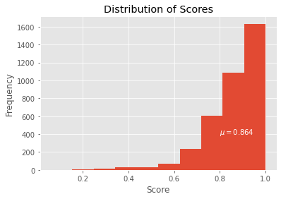

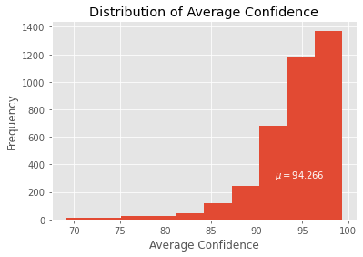

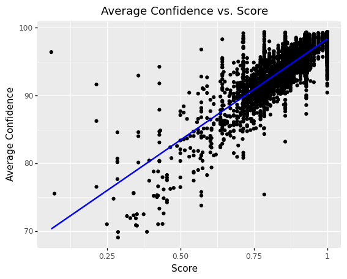

## Analysis

### Summary Statistics

Before performing multiple linear regression on our results, we decided to look at the some of our findings.

First, analyzing average scores for individuals of different dominant hands.

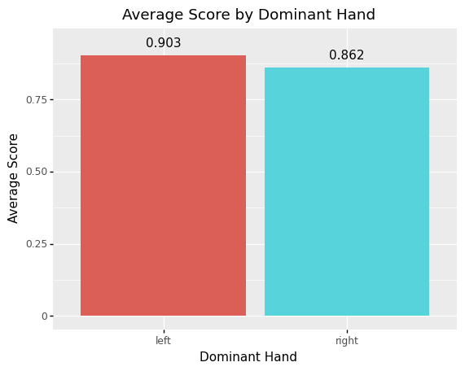

Next, we look at gender differences in Textract accuracy scoring.

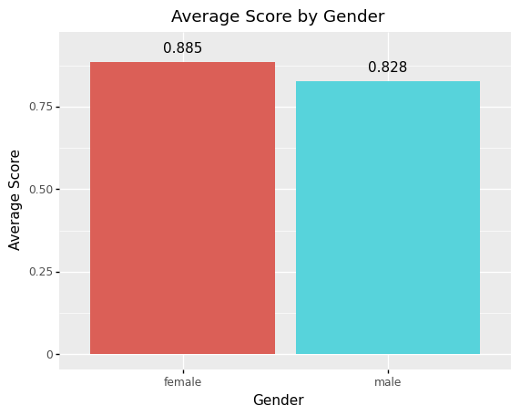

Female sample writers produced samples that were 6% more accurate on average. This suggests that females have better, or at least more readable, handwriting than males. Social differences in expectations for males and females when in school made this result not terribly surprising to us. This variable will be tested later through regression.

We also show the combined relationship between hand and gender below:

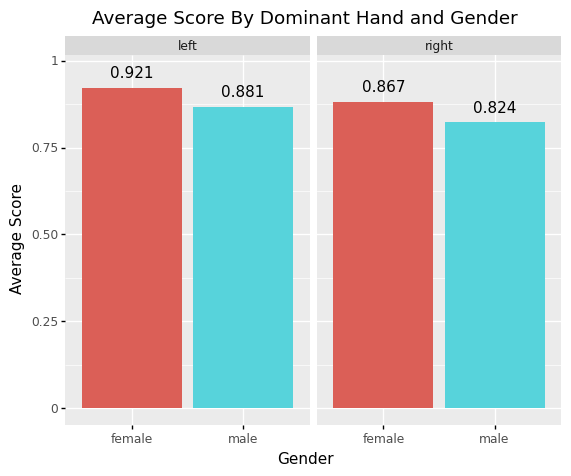

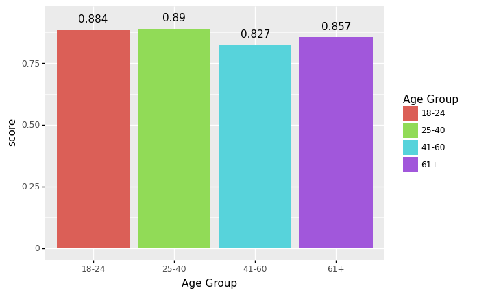

### Regression

To analyze the effect of variables such as age, gender, and dominant hand on Textract's accuracy for the handwriting samples, we devised some multiple linear regression models (MLRM) which are specified as follows:

Model 1: $$score_i = \beta_0 + \beta_1male + u_i $$ Model 2: $$score_i = \beta_0 + \beta_1male + \beta_2right hand + u_i $$ Model 3: $$score_i = \beta_0 + \beta_1male + \beta_2right hand + \beta_3age(25-40) + \beta_4age(41-60) + \beta_5age(61+) + u_i $$

*Note: Female, left hand, and age(18-24) were chosen as our reference groups for the dummy variables gender, dominant hand, and age, respectively.

Here, we explicitly study the effect of these variables on score, which is a direct measure of Textract's accuracy. Through our modeling, we start with simply the gender dummy variable and progressively add more to see if our findings change as more differences in writers are accounted for (which can statsitically only improve the confidence of our findings).

Our null statistical hypothesis is that none of the variables in our model have a serious effect on Textract's accuracy,

To test our hypothesis, we use the F-test for statistical inference, constructed in the following way for Model 3 in particular, as it is our most comprehensive test:

Therefore, if we reject our null hypothesis at a = 0.05 we will have uncovered that at least one variable that affects Textract's transcription accuracy.

Before actually running our regression, we must first motivate a regression approach within our current data set. In other words, to show that our regression model is valid and is the best linear unbiased estimator, we must first satisfy the 5 Gauss Markov Assumptions:

- The form is linear

> Based on our previous construction of each of our models, condition 1 is satisfied because all are linear
- The data has been randomly selected from the population

> As shown below, we have randomly sampled 1,000 participant entries from the entire dataset
- The regressors do not display perfect multicollinearity

> The regression results below do not indicate that there are strong multicollinearity problems
- The regressors are uncorrelated with the residual term

> The mean of the residuals is 0
- The variance of the residual term remains constant

> We assume heteroskedasticity in the model and correct for it using a robust linear regression fitting which corrects our subsequent inference testing

With these conditions satisfied, we know that our inference approach is valid.

|  | *Dependent variable:score* |  |  |
| --- | --- | --- | --- |
|  | (1) | (2) | (3) |
| Intercept | 0.885*** | 0.921*** | 0.935*** |
|  | (0.004) | (0.009) | (0.009) |
| agegroup[T.25-40] |  |  | 0.010 |
|  |  |  | (0.008) |
| agegroup[T.41-60] |  |  | -0.059*** |
|  |  |  | (0.010) |
| agegroup[T.61+] |  |  | -0.024* |
|  |  |  | (0.014) |
| gender[T.male] | -0.055*** | -0.055*** | -0.062*** |
|  | (0.009) | (0.009) | (0.009) |
| hand[T.right] |  | -0.040*** | -0.033*** |
|  |  | (0.009) | (0.009) |
| Observations | 983 | 983 | 983 |
| R<sup>2</sup> | 0.047 | 0.056 | 0.115 |
| Adjusted R<sup>2</sup> | 0.046 | 0.054 | 0.110 |
| Residual Std. Error | 0.116 (df=981) | 0.116 (df=980) | 0.112 (df=977) |
| F Statistic | 35.127*** (df=1; 981) | 23.872*** (df=2; 980) | 16.612*** (df=5; 977) |
| Note: | *p<0.1; **p<0.05; ***p<0.01 |  |  |

```python
#calculation for 4th assumption above - regressors are uncorrelated with the residual term
df['residuals'] = m3.resid
x = df['residuals'].mean()
x
```

```
6.114697309583517e-16
```

*Model 1*

Across the board we see statistically significant coefficients for gender whether it be the only variable specified, or one of several. This suggests that true differences exist in Textract's accuracy to read handwriting samples by writers of different gender identities. As we predicted that male writers would have worse handwriting that is harder to decipher, this is not totally surprising.

*Model 3*

In the final MLRM that we specified, we find that every coefficient, except for that on age(25-40) and agegroup(61+), is statistically significantly different from 0 at the 1% level. We also produce an F statistic of 16.612, which demonstrates that each of the regressors in the model are jointly statistically significantly different from 0 at the 1% level.

This means that age characteristics, as well as the gender and favored hand of a writer, statistically impact Textract's accuracy. In fact, this holds up even at a 99% confidence level! We are very confident that these factors matter. *Why* an individual's righthandedness leads to lower accuracy remains unanswered, but this finding in and of itself is very interesting.

### ANOVA

|  | sum_sq | df | F | PR(>F) |
| --- | --- | --- | --- | --- |
| gender | 0.563667 | 1.0 | 44.919826 | 3.464033e-11 |
| hand | 0.160596 | 1.0 | 12.798239 | 3.639701e-04 |
| agegroup | 0.663506 | 3.0 | 17.625408 | 3.788269e-11 |
| Residual | 12.259669 | 977.0 | NaN | NaN |

Above, we produce an ANOVA table to show a statistically significant variation of means between these groups. Specifically, we see that the F statistic for each variable is very large, and the probability of obtaining that value due to random chance is extremely low. Hence, Textract's accuracy as measured by score is confidently impacted by these variables.

## Conclusion

Here, we have successfully demonstrated that variables such as age group, gender, and dominant hand independently, and jointly have a statistically significant effect on Textract's accuracy. Through both an ANOVA and multiple linear regression model approach, we have shown that many of the coefficients on these variables are statistically significantly different from 0 at the 1% level, highlighting that they may have an important, non-negligible effect on Textract's accuracy. Altogether, this verifies our earlier hypothesis.

## Citations

"Amazon Textract." *Amazon Web Services*, 2021. https://aws.amazon.com/textract/

Crawford, Amy; Ray, Anyesha; Carriquiry, Alicia; Kruse, James; Peterson, Marc (2019): CSAFE Handwriting Database. *Iowa State University*. Dataset. https://doi.org/10.25380/iastate.10062203.v1

Engel-Yeger, Batya, et al. “Age Effects on Sensory-Processing Abilities and Their Impact on Handwriting.” Canadian Journal of Occupational Therapy, vol. 79, no. 5, Dec. 2012, pp. 264–274, doi:10.2182/CJOT.2012.79.5.2.

Yang, Yang et al. “Men and women differ in the neural basis of handwriting.” *Human brain mapping* vol. 41,10 (2020): 2642-2655. doi:10.1002/hbm.24968